# case_study_1

Yongjun Chu

February 23, 2019

```r
library(tidyverse)
```

```r
library(ggplot2)
library(dplyr)
library(tidyr)
```

## Introduction

### The production and sales volumn of craft beer in US have seen steady increases during the last few years. From the point of view of exploring potencial new investment areas and new markets, it is important to gain more insights into the craft beer industry. Based on the two raw datasets related to carft beers and their brewers, we were able to uncover some interesting facts about US craft beer industry.

## Question 1 : how many breweries are present in each state?

### Answer: Since there are so many states, this question is best answered by a bar plot (see below). It was found that Colorado has the most breweries and DC tied with other 3 states has the least.

```r
#upload the two data files: "Beers.csv"" and "Breweries.csv"
beer <- read.csv("C:/Users/chu001/Documents/Yongjun-Chu files/SMU-data-science-application/Doing-Data_Science/Case_study_1/Beers.csv", sep = ',', header = T)
str(beer)
```

```
## 'data.frame':    2410 obs. of  7 variables:
##  $ Name      : Factor w/ 2305 levels "#001 Golden Amber Lager",..: 1638 577 1705 1842 1819 268 1160 758 1093 486 ...
##  $ Beer_ID   : int  1436 2265 2264 2263 2262 2261 2260 2259 2258 2131 ...
##  $ ABV       : num  0.05 0.066 0.071 0.09 0.075 0.077 0.045 0.065 0.055 0.086 ...
##  $ IBU       : int  NA NA NA NA NA NA NA NA NA NA ...
##  $ Brewery_id: int  409 178 178 178 178 178 178 178 178 178 ...
##  $ Style     : Factor w/ 100 levels "","Abbey Single Ale",..: 19 18 16 12 16 80 18 22 18 12 ...
##  $ Ounces    : num  12 12 12 12 12 12 12 12 12 12 ...
```

```r
head(beer)
```

```
##                  Name Beer_ID   ABV IBU Brewery_id
## 1            Pub Beer    1436 0.050  NA        409
## 2         Devil's Cup    2265 0.066  NA        178
## 3 Rise of the Phoenix    2264 0.071  NA        178
## 4            Sinister    2263 0.090  NA        178
## 5       Sex and Candy    2262 0.075  NA        178
## 6        Black Exodus    2261 0.077  NA        178
##                            Style Ounces
## 1            American Pale Lager     12
## 2        American Pale Ale (APA)     12
## 3                   American IPA     12
## 4 American Double / Imperial IPA     12
## 5                   American IPA     12
## 6                  Oatmeal Stout     12
```

```r
#convert all empty or space entries to NA
beer[beer=="" | beer == " "] <- NA
#apply(is.na(beer), 2, which)
sapply(beer, function(x) sum(is.na(x)))
```

```
##       Name    Beer_ID        ABV        IBU Brewery_id      Style
##          0          0         62       1005          0          5
##     Ounces
##          0
```

```r
brewery <- read.csv("C:/Users/chu001/Documents/Yongjun-Chu files/SMU-data-science-application/Doing-Data_Science/Case_study_1/Breweries.csv", sep = ',', header = T)
str(brewery)
```

```
## 'data.frame':    558 obs. of  4 variables:
##  $ Brew_ID: int  1 2 3 4 5 6 7 8 9 10 ...
##  $ Name   : Factor w/ 551 levels "10 Barrel Brewing Company",..: 355 12 266 319 201 136 227 477 59 491 ...
##  $ City   : Factor w/ 384 levels "Abingdon","Abita Springs",..: 228 200 122 299 300 62 91 48 152 136 ...
##  $ State  : Factor w/ 51 levels " AK"," AL"," AR",..: 24 18 20 5 5 41 6 23 23 23 ...
```

```r
head(brewery)
```

```
##   Brew_ID                      Name          City State
## 1       1        NorthGate Brewing    Minneapolis    MN
## 2       2 Against the Grain Brewery    Louisville    KY
## 3       3  Jack's Abby Craft Lagers    Framingham    MA
## 4       4 Mike Hess Brewing Company     San Diego    CA
## 5       5   Fort Point Beer Company San Francisco    CA
## 6       6     COAST Brewing Company    Charleston    SC
```

```r
#convert all empty or space entries to NA
brewery[brewery == "" | brewery == " "] <- NA
sapply(brewery, function(x) sum(is.na(x)))
```

```
## Brew_ID    Name    City   State
##       0       0       0       0
```

```r
#remove the extra empty space before the state name in column State
brewery$State <- as.factor(gsub("^\\s+", "", brewery$State))
str(brewery)
```

```
## 'data.frame':    558 obs. of  4 variables:
##  $ Brew_ID: int  1 2 3 4 5 6 7 8 9 10 ...
##  $ Name   : Factor w/ 551 levels "10 Barrel Brewing Company",..: 355 12 266 319 201 136 227 477 59 491 ...
##  $ City   : Factor w/ 384 levels "Abingdon","Abita Springs",..: 228 200 122 299 300 62 91 48 152 136 ...
##  $ State  : Factor w/ 51 levels "AK","AL","AR",..: 24 18 20 5 5 41 6 23 23 23 ...
```

```r
#or using str_trim to remove the empty space at the beginning/end of a string
#library(stringr)
#brewery$State <- as.factor(str_trim(brewery$State))

library(plyr)
require("gridExtra")
number = count(brewery, 'State')
number
```

```
##    State freq
## 1     AK    7
## 2     AL    3
## 3     AR    2
## 4     AZ   11
## 5     CA   39
## 6     CO   47
## 7     CT    8
## 8     DC    1
## 9     DE    2
## 10    FL   15
## 11    GA    7
## 12    HI    4
## 13    IA    5
## 14    ID    5
```

[output cut: 37 more lines]

```r
unique(number$freq)
```

```
##  [1]  7  3  2 11 39 47  8  1 15  4  5 18 22 23  9 32 12 19 16  6 29 25 28
## [24] 10 20
```

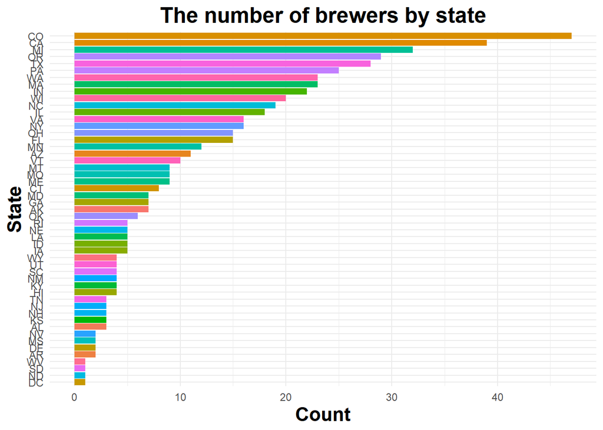

```r
#another way to solve this question
#brewery %>% group_by(State) %>% dplyr::summarise(brew_per_state =length(Brew_ID))

#ggplot the freq of brewery for each state in decreasing order
p = ggplot(number, aes(x=reorder(State, freq), y=freq, fill=State)) + geom_bar(stat="identity") + labs(title="The number of brewers by state",
         x="State", y = "Count") + theme_minimal() + coord_flip() + theme(legend.position="none") + theme(plot.title=element_text(hjust=0.5, size = 18, face = "bold"), axis.title = element_text(size = 16, face = "bold"))
p
```

## Question 2: Merge beer data with the breweries data. Print the first 6 observations and the last six observations to check the merged file.

### Answer: the two files was merged based on the brewer ID. There are 2410 rows. The first and last 6 rows of the merged file are shown below.

```r
#merge two data frames
colnames(beer)[1] <- "Name_beer"
colnames(beer)[5] <- "Brew_ID"
colnames(brewery)[2] <- "Name_brew"
total = merge(beer, brewery, by.x="Brew_ID", by.y="Brew_ID", all = T)
nrow(total)
```

```
## [1] 2410
```

```r
head(total)
```

```
##   Brew_ID     Name_beer Beer_ID   ABV IBU
## 1       1  Get Together    2692 0.045  50
## 2       1 Maggie's Leap    2691 0.049  26
## 3       1    Wall's End    2690 0.048  19
## 4       1       Pumpion    2689 0.060  38
## 5       1    Stronghold    2688 0.060  25
## 6       1   Parapet ESB    2687 0.056  47
##                                 Style Ounces          Name_brew
## 1                        American IPA     16 NorthGate Brewing
## 2                  Milk / Sweet Stout     16 NorthGate Brewing
## 3                   English Brown Ale     16 NorthGate Brewing
## 4                         Pumpkin Ale     16 NorthGate Brewing
## 5                     American Porter     16 NorthGate Brewing
## 6 Extra Special / Strong Bitter (ESB)     16 NorthGate Brewing
##          City State
## 1 Minneapolis    MN
## 2 Minneapolis    MN
## 3 Minneapolis    MN
## 4 Minneapolis    MN
## 5 Minneapolis    MN
## 6 Minneapolis    MN
```

```r
tail(total)
```

```
##      Brew_ID                 Name_beer Beer_ID   ABV IBU
## 2405     556             Pilsner Ukiah      98 0.055  NA
## 2406     557  Heinnieweisse Weissebier      52 0.049  NA
## 2407     557           Snapperhead IPA      51 0.068  NA
## 2408     557         Moo Thunder Stout      50 0.049  NA
## 2409     557         Porkslap Pale Ale      49 0.043  NA
## 2410     558 Urban Wilderness Pale Ale      30 0.049  NA
##                        Style Ounces                     Name_brew
## 2405         German Pilsener     12         Ukiah Brewing Company
## 2406              Hefeweizen     12       Butternuts Beer and Ale
## 2407            American IPA     12       Butternuts Beer and Ale
## 2408      Milk / Sweet Stout     12       Butternuts Beer and Ale
## 2409 American Pale Ale (APA)     12       Butternuts Beer and Ale
## 2410        English Pale Ale     12 Sleeping Lady Brewing Company
##               City State
## 2405         Ukiah    CA
## 2406 Garrattsville    NY
## 2407 Garrattsville    NY
## 2408 Garrattsville    NY
## 2409 Garrattsville    NY
## 2410     Anchorage    AK
```

```r
str(total)
```

```
## 'data.frame':    2410 obs. of  10 variables:
##  $ Brew_ID  : int  1 1 1 1 1 1 2 2 2 2 ...
##  $ Name_beer: Factor w/ 2305 levels "#001 Golden Amber Lager",..: 802 1258 2185 1640 1926 1525 458 1218 43 71 ...
##  $ Beer_ID  : int  2692 2691 2690 2689 2688 2687 2686 2685 2684 2683 ...
##  $ ABV      : num  0.045 0.049 0.048 0.06 0.06 0.056 0.08 0.125 0.077 0.042 ...
##  $ IBU      : int  50 26 19 38 25 47 68 80 25 42 ...
##  $ Style    : Factor w/ 100 levels "","Abbey Single Ale",..: 16 77 48 83 22 57 12 46 77 18 ...
##  $ Ounces   : num  16 16 16 16 16 16 16 16 16 16 ...
##  $ Name_brew: Factor w/ 551 levels "10 Barrel Brewing Company",..: 355 355 355 355 355 355 12 12 12 12 ...
##  $ City     : Factor w/ 384 levels "Abingdon","Abita Springs",..: 228 228 228 228 228 228 200 200 200 200 ...
##  $ State    : Factor w/ 51 levels "AK","AL","AR",..: 24 24 24 24 24 24 18 18 18 18 ...
```

```r
#find the situation in St Lois or Budweiser
#head(total %>% select(Name_beer, Beer_ID, ABV, IBU, Style, Name_brew, City, State))
total %>% filter(grepl("Saint Louis", total$City))
```

```
##    Brew_ID                   Name_beer Beer_ID   ABV IBU
## 1       61       Passion Fruit Prussia    2545 0.035  11
## 2       61                   Send Help    2544 0.045  18
## 3       61     Cast Iron Oatmeal Brown    2324 0.055  NA
## 4       61      Reprise Centennial Red    2288 0.060  NA
## 5       61                   Alter Ego    2287 0.055  NA
## 6       61                 Divided Sky    2286 0.065  NA
## 7       61                 Resurrected    2285 0.065  NA
## 8       61                Contact High    1870 0.050  28
## 9      327    When Helles Freezes Over    1756 0.056  18
## 10     327   Morgan Street Oktoberfest    1617 0.049  24
## 11     327                 Honey Wheat    1052 0.047  14
## 12     327       Black Bear Dark Lager    1051 0.046  24
## 13     327              Golden Pilsner    1046 0.050  35
## 14     429   Schlafly Yakima Wheat Ale    1324 0.050  45
```

[output cut: 45 more lines]

```r
total %>% filter(grepl("Budweiser", total$Name_beer))
```

```
##  [1] Brew_ID   Name_beer Beer_ID   ABV       IBU       Style     Ounces
##  [8] Name_brew City      State
## <0 rows> (or 0-length row.names)
```

## Question 3:report the total of rows having ‘NA’ in each column

### Answer: the output from sapply shows that there are 62 NAs in ABV column, 1005 in IBU column and 5 in Style.

```r
#Report the exact rows having NA in each column
#apply(is.na(total), 2, which)

#head(total, n=20)

#report the total of rows having 'NA' in each column
number_NA <- sapply(total, function(x) sum(is.na(x)))
class(number_NA)
```

```
## [1] "integer"
```

```r
number_NA
```

```
##   Brew_ID Name_beer   Beer_ID       ABV       IBU     Style    Ounces
##         0         0         0        62      1005         5         0
## Name_brew      City     State
##         0         0         0
```

## Question 4: Compute the median alcohol content and international bitterness unit for each state. Plot a bar chart to compare

### Answer: two bar graphs were generated for ABV and IBU, respectively.

```r
str(total)
```

```
## 'data.frame':    2410 obs. of  10 variables:
##  $ Brew_ID  : int  1 1 1 1 1 1 2 2 2 2 ...
##  $ Name_beer: Factor w/ 2305 levels "#001 Golden Amber Lager",..: 802 1258 2185 1640 1926 1525 458 1218 43 71 ...
##  $ Beer_ID  : int  2692 2691 2690 2689 2688 2687 2686 2685 2684 2683 ...
##  $ ABV      : num  0.045 0.049 0.048 0.06 0.06 0.056 0.08 0.125 0.077 0.042 ...
##  $ IBU      : int  50 26 19 38 25 47 68 80 25 42 ...
##  $ Style    : Factor w/ 100 levels "","Abbey Single Ale",..: 16 77 48 83 22 57 12 46 77 18 ...
##  $ Ounces   : num  16 16 16 16 16 16 16 16 16 16 ...
##  $ Name_brew: Factor w/ 551 levels "10 Barrel Brewing Company",..: 355 355 355 355 355 355 12 12 12 12 ...
##  $ City     : Factor w/ 384 levels "Abingdon","Abita Springs",..: 228 228 228 228 228 228 200 200 200 200 ...
##  $ State    : Factor w/ 51 levels "AK","AL","AR",..: 24 24 24 24 24 24 18 18 18 18 ...
```

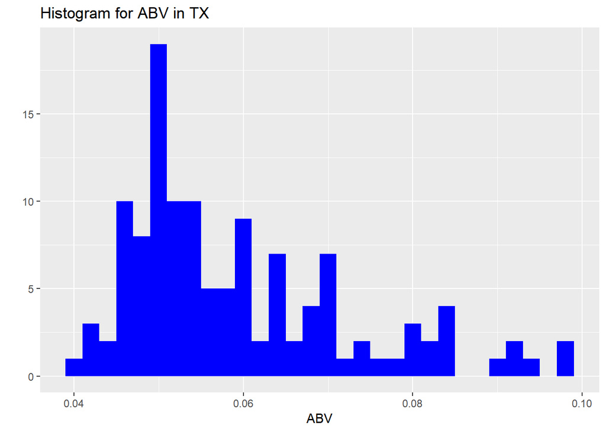

```r
#get the histogram of ABV and IBU for TX:
qplot(total$ABV[total$State == "TX"],
      geom="histogram",
      binwidth = 0.002,
      main = "Histogram for ABV in TX",
      xlab = "ABV",
      fill=I("blue"))
```

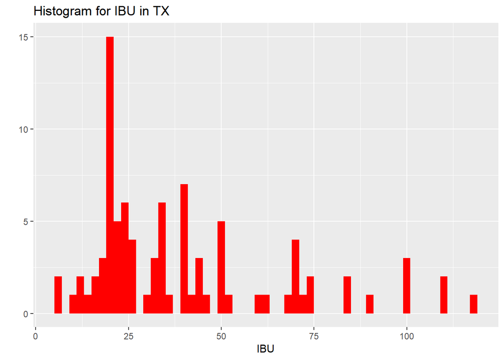

```r
qplot(total$IBU[total$State == "TX"],
      geom="histogram",
      binwidth = 2,
      main = "Histogram for IBU in TX",
      xlab = "IBU",
      fill=I("red"))
```

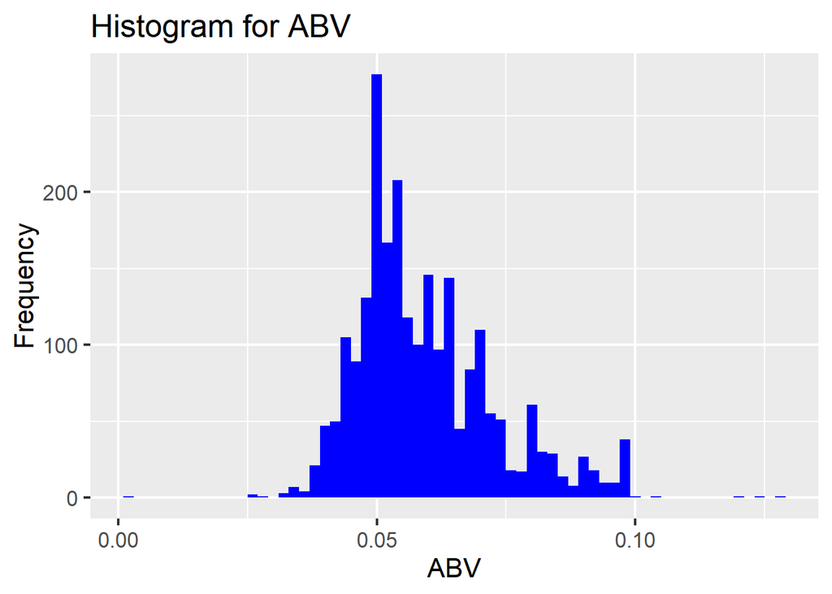

```r
#get the histogram of ABV and IBU for all states:
qplot(total$ABV,
      geom="histogram",
      binwidth = 0.002,
      main = "Histogram for ABV",
      xlab = "ABV",
      ylab="Frequency",
      fill=I("blue")) + theme_grey(base_size = 16)
```

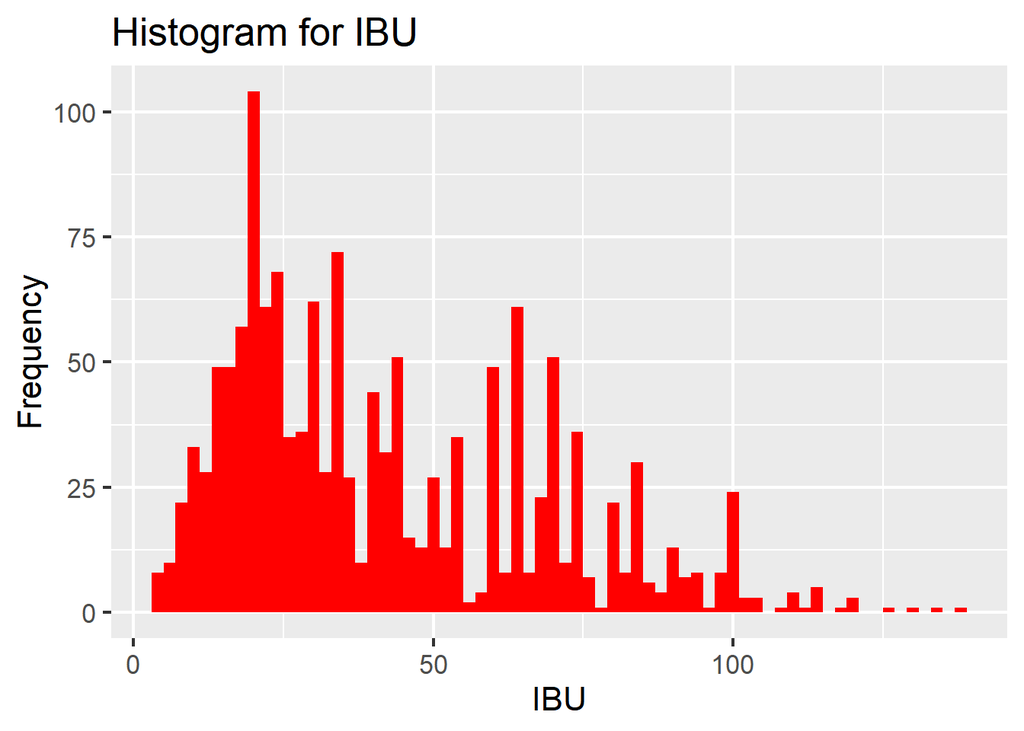

```r
qplot(total$IBU,
      geom="histogram",
      binwidth = 2,
      main = "Histogram for IBU",
      xlab = "IBU",
      ylab="Frequency",
      fill=I("red"))+ theme_grey(base_size = 16)
```

```r
#ggplot(data=total, aes(total$ABV)) + geom_histogram()

#get median ABV and IBU for each state
median <-  total %>% group_by(State) %>% dplyr::summarise(median_ABV=median(ABV, na.rm = T),median_IBU = median(IBU,na.rm=T) )
median
```

```
## # A tibble: 51 x 3
##    State median_ABV median_IBU
##    <fct>      <dbl>      <dbl>
##  1 AK        0.056        46
##  2 AL        0.06         43
##  3 AR        0.052        39
##  4 AZ        0.055        20.5
##  5 CA        0.058        42
##  6 CO        0.0605       40
##  7 CT        0.06         29
##  8 DC        0.0625       47.5
##  9 DE        0.055        52
## 10 FL        0.057        55
## # ... with 41 more rows
```

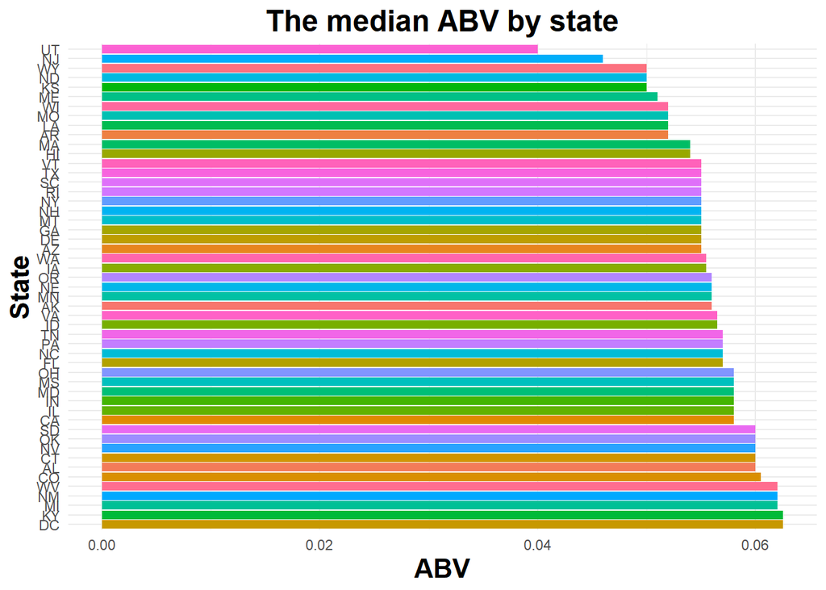

```r
#plot a bar graph to compare ABV
ggplot(median, aes(x=reorder(State, -median_ABV),y=median_ABV, fill=State)) + geom_bar(stat = 'identity') + labs(title="The median ABV by state",
         x="State", y = "ABV") +  theme_minimal() + coord_flip() + theme(legend.position="none") + theme(plot.title=element_text(hjust=0.5, size=18,face = "bold"), axis.title = element_text(size = 16, face = "bold"))
```

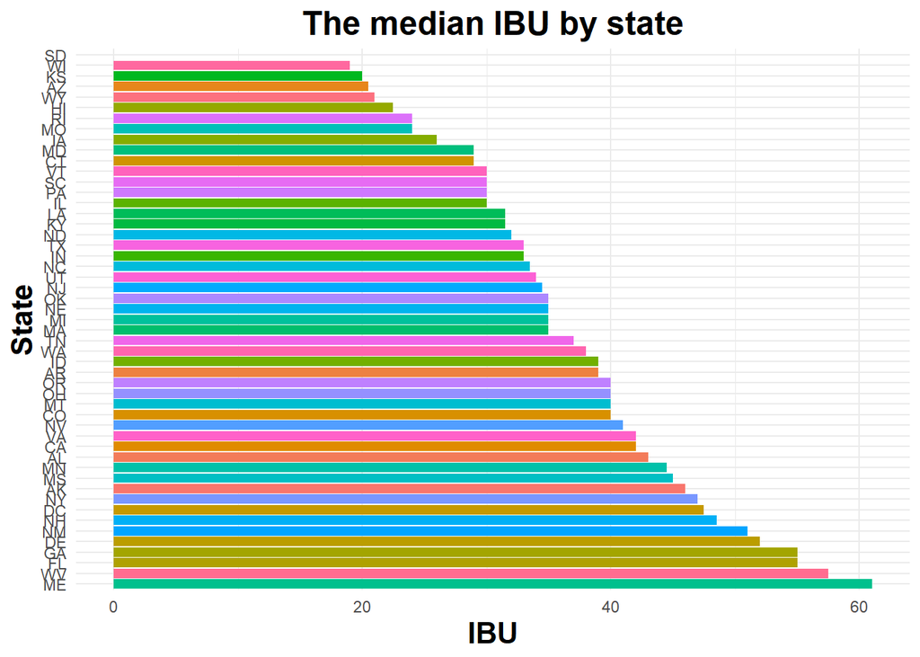

```r
#plot a bar graph to compare IBU
ggplot(median, aes(x=reorder(State, -median_IBU),y=median_IBU, fill=State)) + geom_bar(stat = 'identity') + labs(title="The median IBU by state",
         x="State", y = "IBU") + theme_minimal() + coord_flip() + theme(legend.position="none") + theme(plot.title=element_text(hjust=0.5, size=18,face = "bold"), axis.title = element_text(size = 16, face = "bold"))
```

## question 5: Which state has the maximum alcoholic (ABV) beer? Which state has the most bitter (IBU) beer?

### Answer: Colorado has the maximum ABV beer and Oregon has the most bitter beer.

```r
#Which state has the maximum alcoholic (ABV) beer? Which state has the most bitter #(IBU) beer?
#
max <- total %>% group_by(State) %>% dplyr::summarise(max_ABV=max(ABV, na.rm = T),max_IBU = max(IBU,na.rm=T) )
max
```

```
## # A tibble: 51 x 3
##    State max_ABV max_IBU
##    <fct>   <dbl>   <dbl>
##  1 AK      0.068      71
##  2 AL      0.093     103
##  3 AR      0.061      39
##  4 AZ      0.095      99
##  5 CA      0.099     115
##  6 CO      0.128     104
##  7 CT      0.09       85
##  8 DC      0.092     115
##  9 DE      0.055      52
## 10 FL      0.082      82
## # ... with 41 more rows
```

```r
top_5_ABV <- arrange(max, -max_ABV)[1:5,]
print(top_5_ABV)
```

```
## # A tibble: 5 x 3
##   State max_ABV max_IBU
##   <fct>   <dbl>   <dbl>
## 1 CO      0.128     104
## 2 KY      0.125      80
## 3 IN      0.12      115
## 4 NY      0.1       111
## 5 CA      0.099     115
```

```r
top_5_IBU <- arrange(max, -max_IBU)[1:5,]
print(top_5_IBU)
```

```
## # A tibble: 5 x 3
##   State max_ABV max_IBU
##   <fct>   <dbl>   <dbl>
## 1 OR      0.088     138
## 2 VA      0.088     135
## 3 MA      0.099     130
## 4 OH      0.099     126
## 5 MN      0.099     120
```

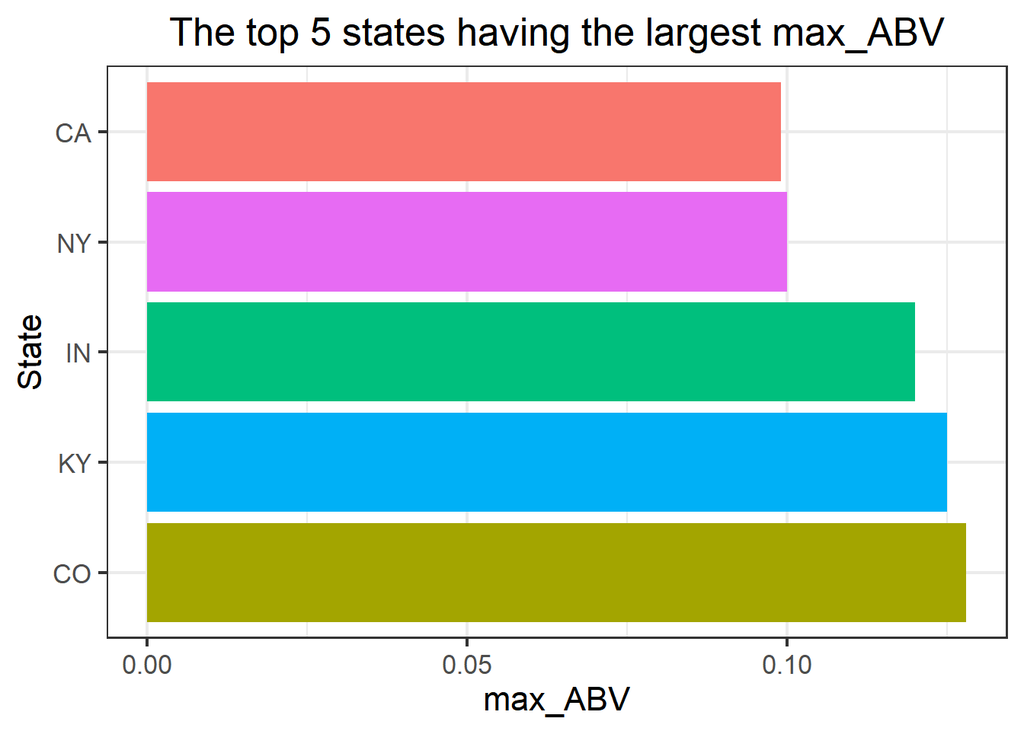

```r
#sub_max_ABV <- filter(max, State == " CO"|State ==" KY"|State ==" IN"|State ==" NY"|State ==" CA")
#sub_max_IBU <- filter(max, State == " OR"|State ==" VA"|State ==" MA"|State ==" OH"|State ==" MN")

#plot a bar graph to compare max ABV for top 5 states
ggplot(top_5_ABV, aes(x=reorder(State, -max_ABV),y=max_ABV, fill=State)) + geom_bar(stat = 'identity') + labs(title="The top 5 states having the largest max_ABV",
          x="State", y = "max_ABV") + theme_minimal() + coord_flip()+  theme_bw(base_size=16) + theme(legend.position="none") + theme(plot.title=element_text(hjust=0.5))
```

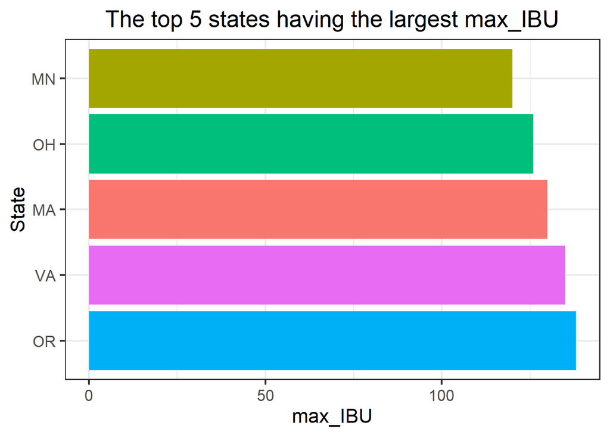

```r
#plot a bar graph to compare max IBU for top 5 states
ggplot(top_5_IBU, aes(x=reorder(State, -max_IBU),y=max_IBU, fill=State)) + geom_bar(stat = 'identity') + labs(title="The top 5 states having the largest max_IBU",
          x="State", y = "max_IBU") + theme_minimal() + coord_flip()+  theme_bw(base_size=16) + theme(legend.position="none") + theme(plot.title=element_text(hjust=0.5))
```

```r
max_ABV_state <- filter(max, max_ABV == max(max_ABV))
max_ABV_state
```

```
## # A tibble: 1 x 3
##   State max_ABV max_IBU
##   <fct>   <dbl>   <dbl>
## 1 CO      0.128     104
```

```r
max_IBU_state <- filter(max, max_IBU == max(max_IBU))
max_IBU_state
```

```
## # A tibble: 1 x 3
##   State max_ABV max_IBU
##   <fct>   <dbl>   <dbl>
## 1 OR      0.088     138
```

## Question 6: Summary statistics for the ABV variable.

### Answer: min: 0.001; median: 0.056, Mean: 0.05977, and mx: 0.128

```r
summary(total$ABV, na.rm=T)
```

```
##    Min. 1st Qu.  Median    Mean 3rd Qu.    Max.    NA's
## 0.00100 0.05000 0.05600 0.05977 0.06700 0.12800      62
```

```r
summary(total$IBU, na.rm=T)
```

```
##    Min. 1st Qu.  Median    Mean 3rd Qu.    Max.    NA's
##    4.00   21.00   35.00   42.71   64.00  138.00    1005
```

## question 7: Is there an apparent relationship between the bitterness of the beer and its alcoholic content? Draw a scatter plot.

### Answer: Yes. the Pearson correlation coefficinet is r = 0.67 (p-value <0.0001). This fitting curve suggests a roughly linear relationship between these two.

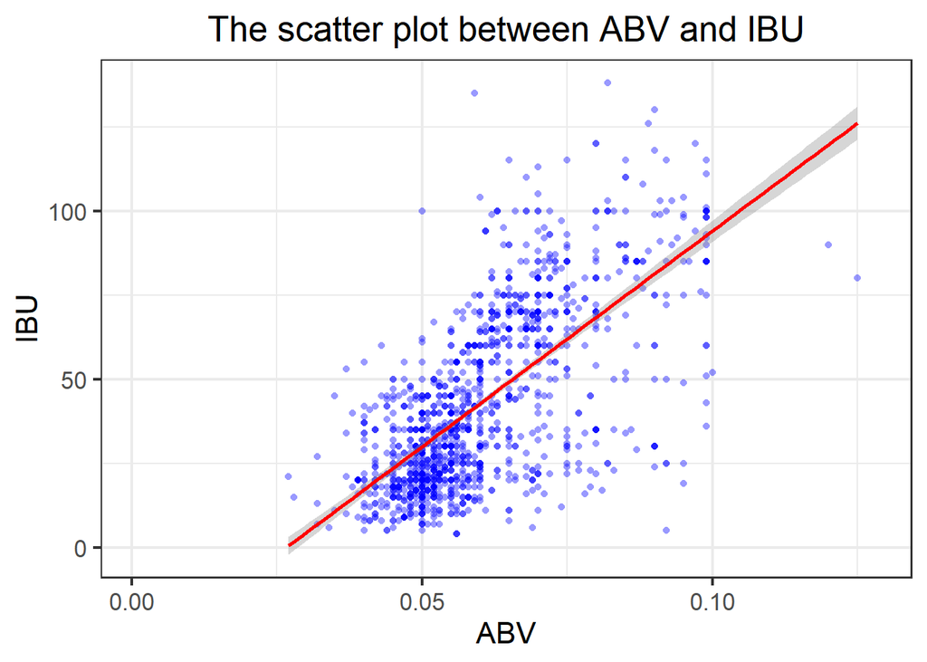

```r
#a scatter plot should solve this problem
ggplot(total, aes(x=ABV, y=IBU)) + geom_point(color="blue", size=1.5, alpha=0.4, pch=16)+ theme_bw(base_size=16) + geom_smooth(method = "lm", se = T, color="red") + labs(title="The scatter plot between ABV and IBU") + theme(legend.position="none") + theme(plot.title=element_text(hjust=0.5))
```

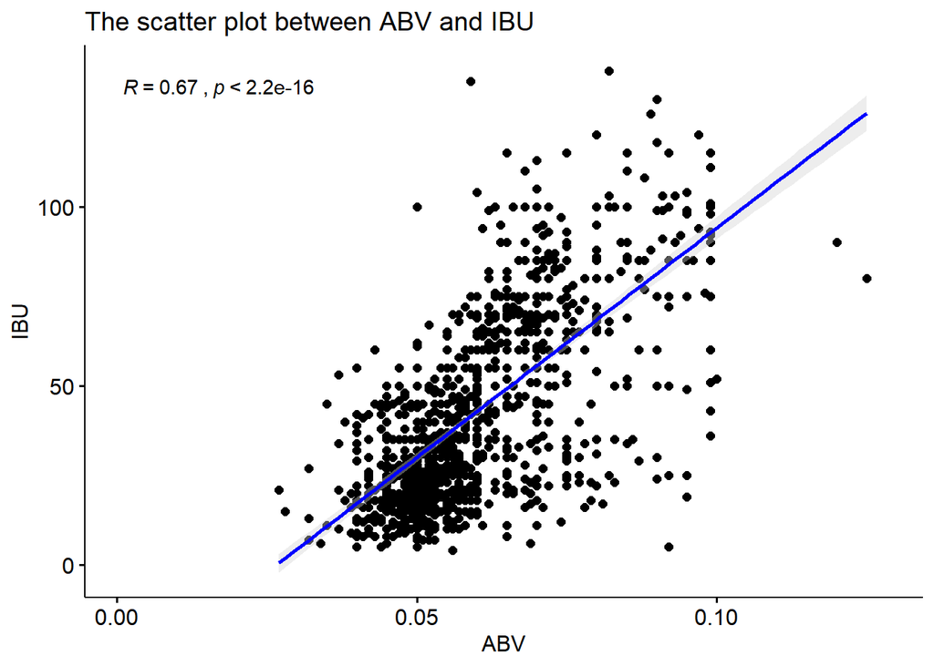

```r
total$IBU <- as.numeric(total$IBU)

#the cor function is not working becaue of the NA in the data
#corr_coef <- round(cor(total$ABV, total$IBU), digits = 2)
#corr_coef

#We can draw the plot with ggscatter.
library("ggpubr")
ggscatter(total, x = "ABV", y = "IBU", color = "black",
          add = "reg.line", conf.int = TRUE,
          cor.coef = TRUE, cor.method = "pearson", add.params = list(color = "blue", fill = "lightgray"),
          xlab = "ABV", ylab = "IBU", title="The scatter plot between ABV and IBU")
```

## Conclusions

### We have made several interesting findings about the craft beer industry in US. In terms of which state has the most craft beer brewers, Colorado takes the number 1 spot, followed by California, Michigan, Orogen and Texas, all in midwest/west region. When comparing the alcohol content (ABV) in all the beers produced in each state, washington DC has the highest median ABV value at 0.0625. For beer bitness (IBU) comparison, Maine took the top spot. When searching for the state producing the largest ABV beer, we found that Colorado is on the top. We also found that Oregon produces the most bitness beer in the nation, with IBU value of 138. Finally, it was found that there is a significant correlation between alcohol content and beer bitness among all the craft beer in the US (r =0.67, p-value < 0.0001).

## The link to the presentation video is: https://www.screencast.com/t/uKGLXQkN